# Projet_IF36

kiki la petite sorcière

2026-04-20

# Introduction

Dans le cadre de l’UE d’IF36, nous souhaitons utiliser des données nombreuses et variées sur un thème précis afin d’étudier des corrélations, des tendances et autres liens. Pour ce faire, nous utiliserons différents outils pour créer des graphiques simples à comprendre et à lire.

[figure not shown]

Valorant sera le support de nos données. Il s’agit d’un jeu de tir par équipe. Il existe de nombreux personnages uniques, ainsi que des cartes et des armes variées. On y trouve également également une scène compétitive très développée, avec des milliers de joueurs professionnels. Ces innombrables données permettront de répondre à toutes les questions que nous avons sur le jeu et ses joueurs.

La description détaillée des datasets mobilisés est à retrouver dans le README.md de notre repo.

## ⚠️ IMPORTANT: Comment lire les données

La plupart des données sont accessibles après un simple git clone ou git pull au format csv. Seule l’archive .zip du dataset 3 nécessite d’être extraite, et renommer le dossier résultant avec exactement le même nom que l’archive (sans le .zip): “3. Valorant Champion Tour 2021-2026 Data”.

Ainsi, le code devrait compiler et le knit devrait normalement marcher.

# 1. Quelles sont les différences majeures entre les joueurs pros et non pros ?

Chaque joueur a ses forces et ses faiblesses, au fur et à mesure de son évolution. Nous nous demanderons donc ce qui démarque un joueur pro d’un joueur amateur, sur quels domaines un joueur professionnel est il plus performant ? Est ce que chaque joueur a sa spécialité poussée au maximum ? Est-ce que certains aspects changent peu entre un joueur professionnel et un joueur amateur ? Pour le savoir nous allons comparer les statistiques de jeu des deux catégories de joueurs.

Tout d’abord, regardons les kills par rapport aux morts des joueurs. Un joueur professionnel meurt il moins souvent qu’un joueur amateur ?

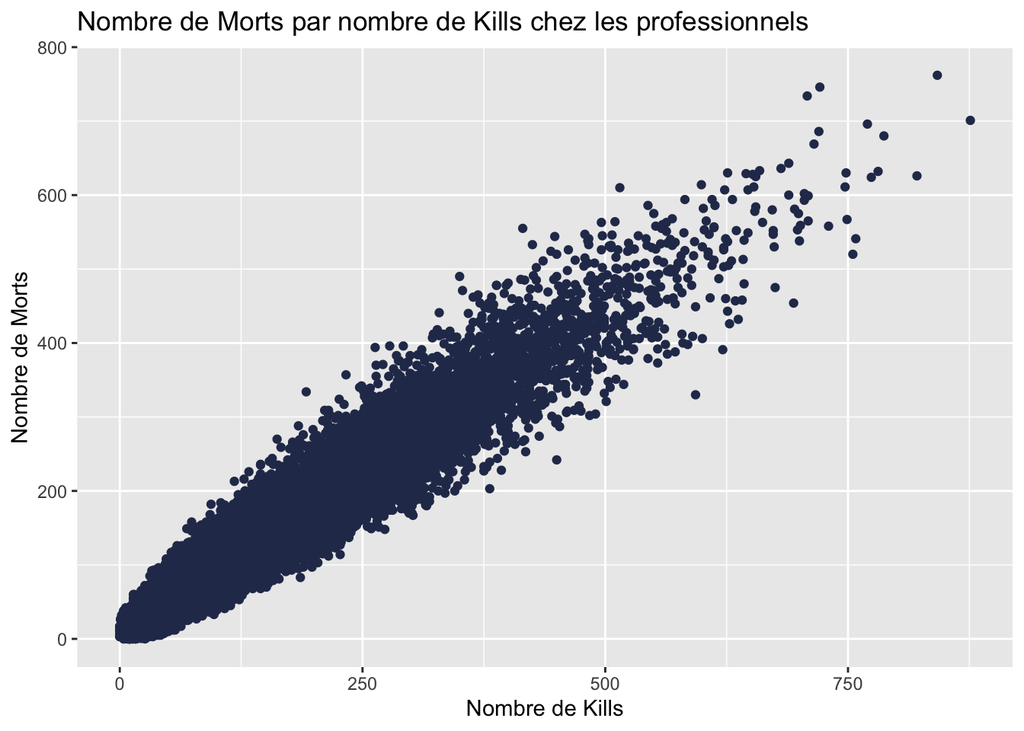

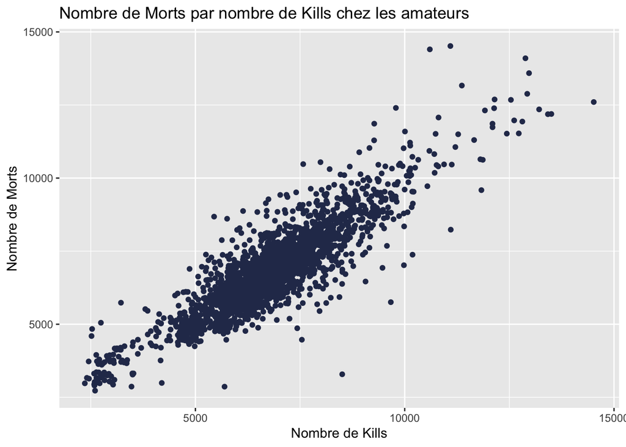

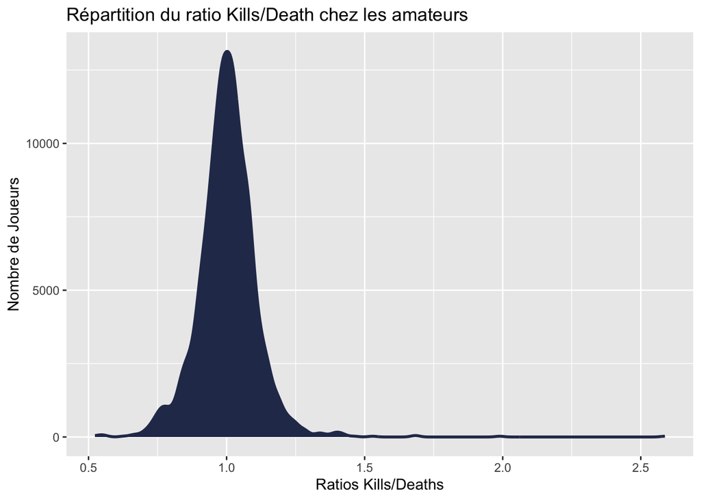

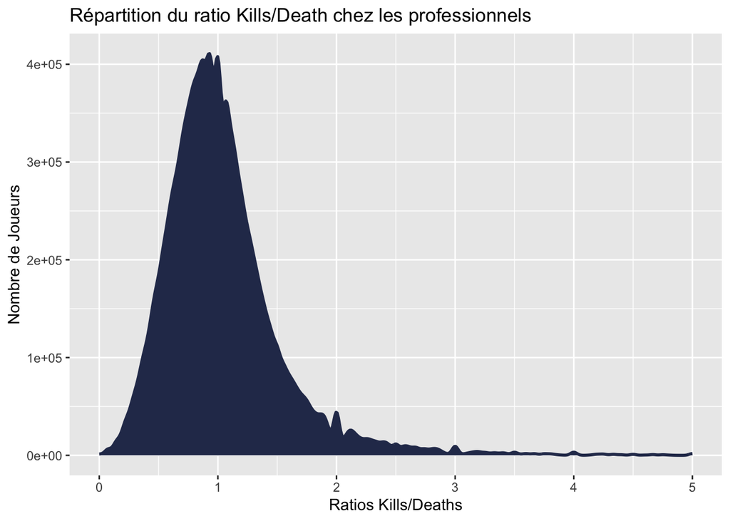

On peut observer que la majorité des joueurs ont effectivement un ratio Kills/deaths qui tourne autour de 1.On peut également observer qu’il y a davantage de joueurs qui ont un ratio au dela de 1 chez les professionnels.

Nous allons désormais nous concentrer sur une autre statistique importante du jeu : le pourcentage de tirs dans la tete. Cette statistique nous permettra d’observer la précision des joueurs professionnels et amateurs. Nous nous attendons à ce que les joueurs professionnels soient plus précis que les joueurs amateurs.

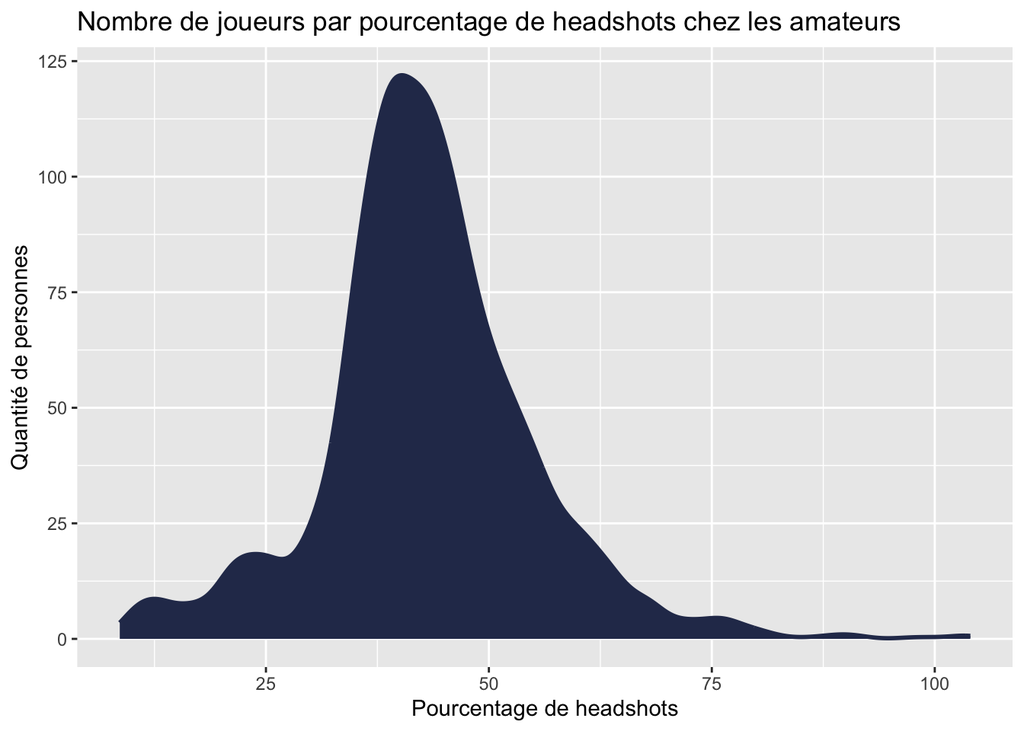

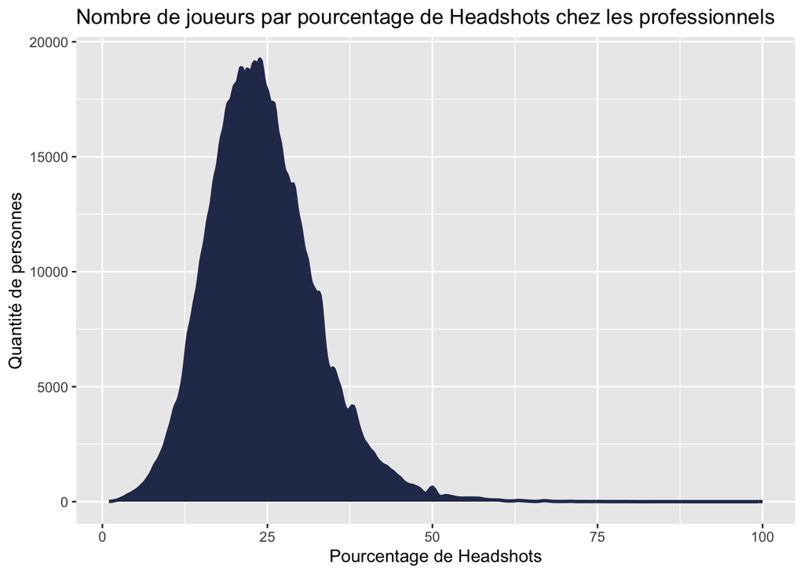

## Interprétation

# 2. Quels personnages sont les plus meurtriers ?

En prenant en compte seulement les joueurs non pros pour plus de “réalisme”, on veut voir si des agents vont avoir une quantité d’éliminations / de dégâts largement supérieure, et voir à l’inverse quels agents mettent le moins de dégâts et font le moins de kills. On pourra éventuellement faire le lien ensuite avec les compétences de ces agents, pour voir si le résultat s’explique ou non.

Pour éviter les données de joueurs pros, nous allons utiliser le dataset [“Agents Stats” de blitz.gg](https://blitz.gg/valorant/stats/agents). Pour exploiter les données du site, nous avons réussi à trouver [l’API interne](https://data.v2.iesdev.com/api/v1/query_objects/prod/val/agent_stats?tier=18%2B&queue=competitive&map=ALL&ep_act=ev26actiii) qui renvoie tout un tas de statistiques intéressantes qui ne sont d’ailleurs pas visibles sur la page. Ces statistiques concernent tous les agents sur toutes les maps, pour les matchs en mode compétitif pour les rangs Diamant et +, lors de la dernière saison.

On peut commencer par comparer simplement le nombre de kills pour chaque agent. Seulement, il est possible que tous les agents ne soient pas choisis par les joueurs dans des proportions égales. Si c’est le cas, alors c’est un paramètre qu’il faut prendre en compte. Alors commençons par s’intéresser au nombre de kills en fonction du nombre de matchs joués.

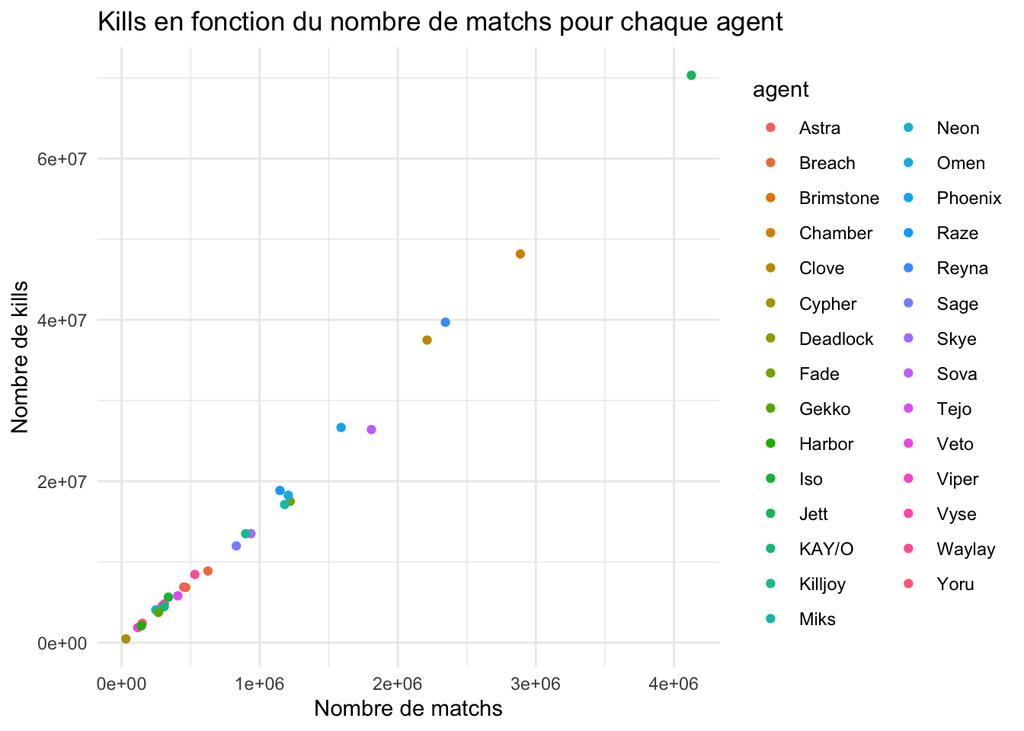

Comme il est difficile de voir réellement les agents sur le graphique, voici les agents classés par nombre de matchs joués pour pouvoir faire le lien.

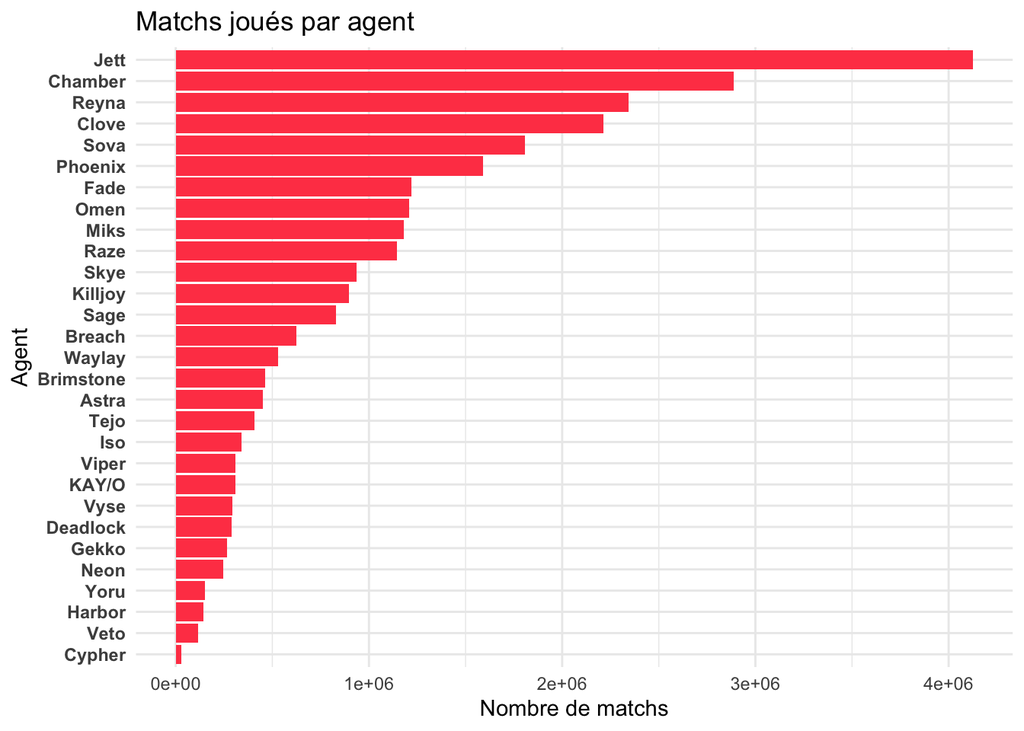

On remarque tout de suite une forte corrélation entre nombre de kills et nombre de matchs: c’est quasiment une fonction linéaire. Cela montre bien que les agents sont choisis de manière très inégale (et on retient que Jett est le personnage le plus joué de loin), et que l’on ne pourra pas tirer de conclusions intéressantes si on ne prend pas en compte le nombre de matchs pour chaque agent. Il faut se débrouiller pour observer des moyennes ou des ratios de plusieurs façons. Commençons par une statistique importante et connue: le Kills/Deaths ratio, qui nous permettra de voir quels agents meurent plus qu’ils ne tuent en moyenne.

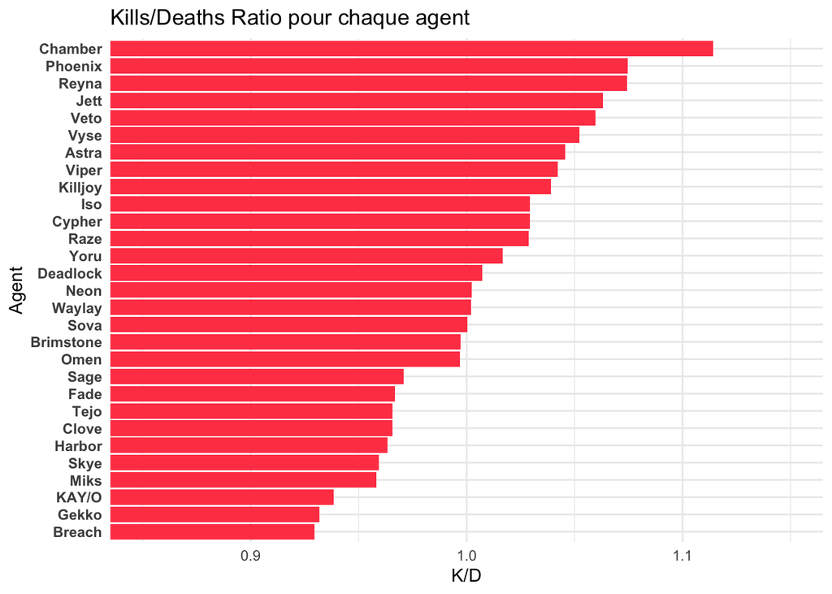

On remarque que le personnage de Jett a un bon KD, mais ce n’est pas le plus haut non plus. On remarque bien sûr le KD de Chamber, le plus haut et le seul supérieur à 1.1.

Avec la stat matchesPlayed, on peut essayer de s’intéresser au nombre de kills par match en moyenne pour chaque agent. Cela peut nous permettre de mieux comprendre quels agents ont des styles de jeu plus agressifs. Nous verrons par la même occasion si les tendances précédentes se confirment.

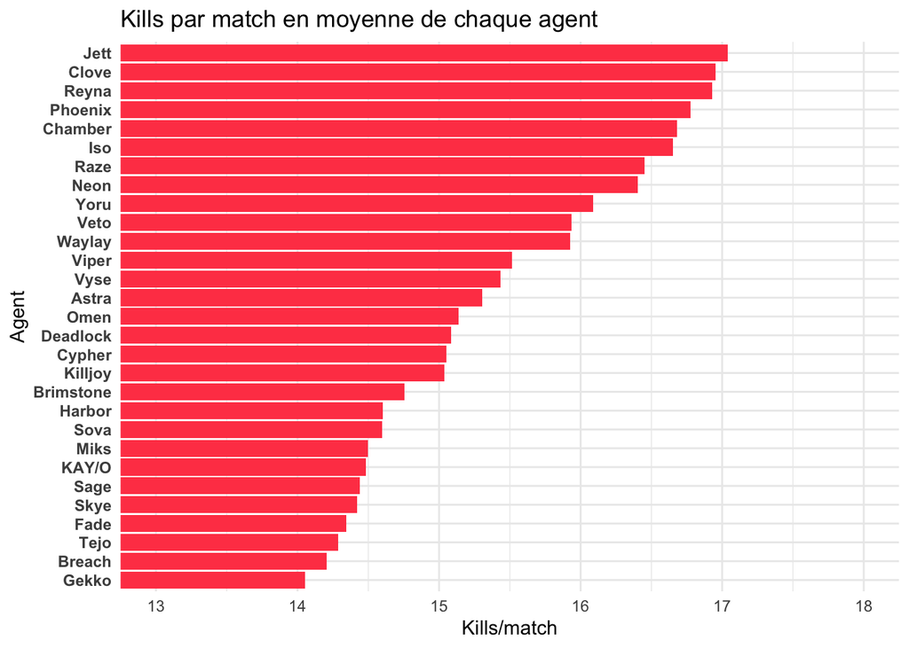

## Interprétation

En somme, Jett a des très bonnes stats dans toutes les données que nous avons explorées. On a remarqué aussi que c’est le personnage le plus populaire, et c’est probablement dû justement à son style de jeu agressif et qui génère des kills que nous avons pu le constater. Les autres personnages avec de bons KD et kills comme Chamber, Phoenix et Reyna font aussi partie des personnages les plus choisis. On peut donc se douter que ce qui fait leur popularité est précisément leur set de compétences qui leur permet d’être des personnages au coeur de l’action régulièrement.

# 3. Quels joueurs pros ont la carrière la plus prolifique ?

Dans cette partie, nous allons tenter de répondre à la question suivante : **Quels joueurs pros ont la carrière la plus prolifique ?** L’idée de cette question est d’observer les joueurs prometteurs pour voir où est ce qu’on les retrouvera dans d’autres analyses.

Dans l’idée, nous souhaitons réaliser un barchart permettant de voir les 10 meilleurs joueurs de chaque année, afin d’en observer l’évolution.

### Graphiques des meilleurs joueurs de chaque année

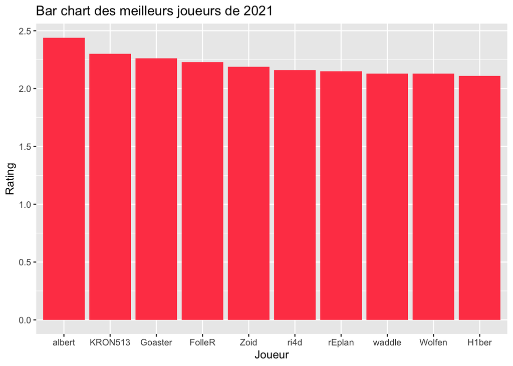

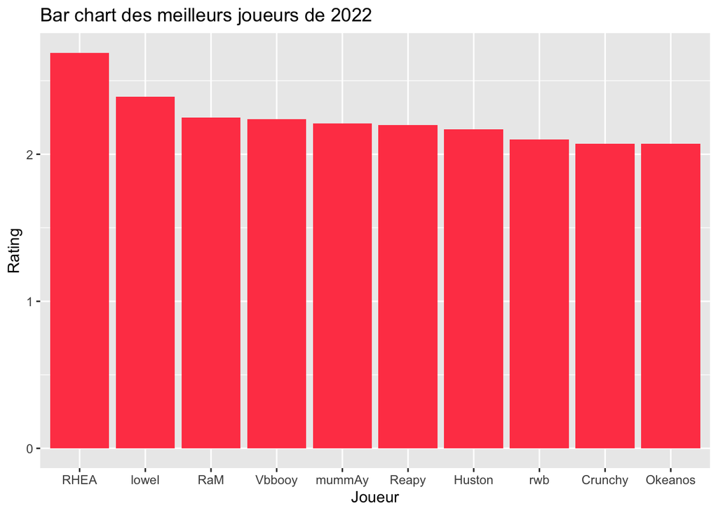

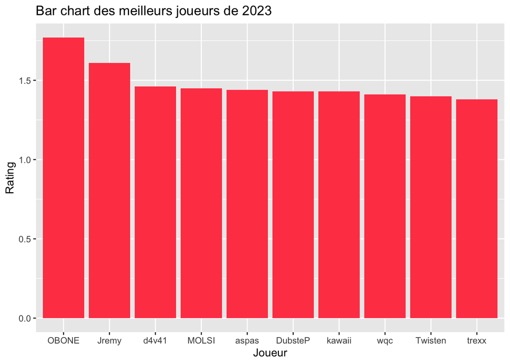

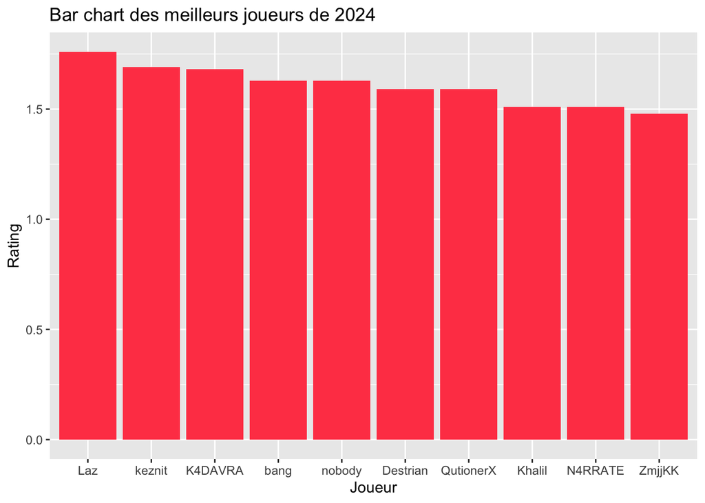

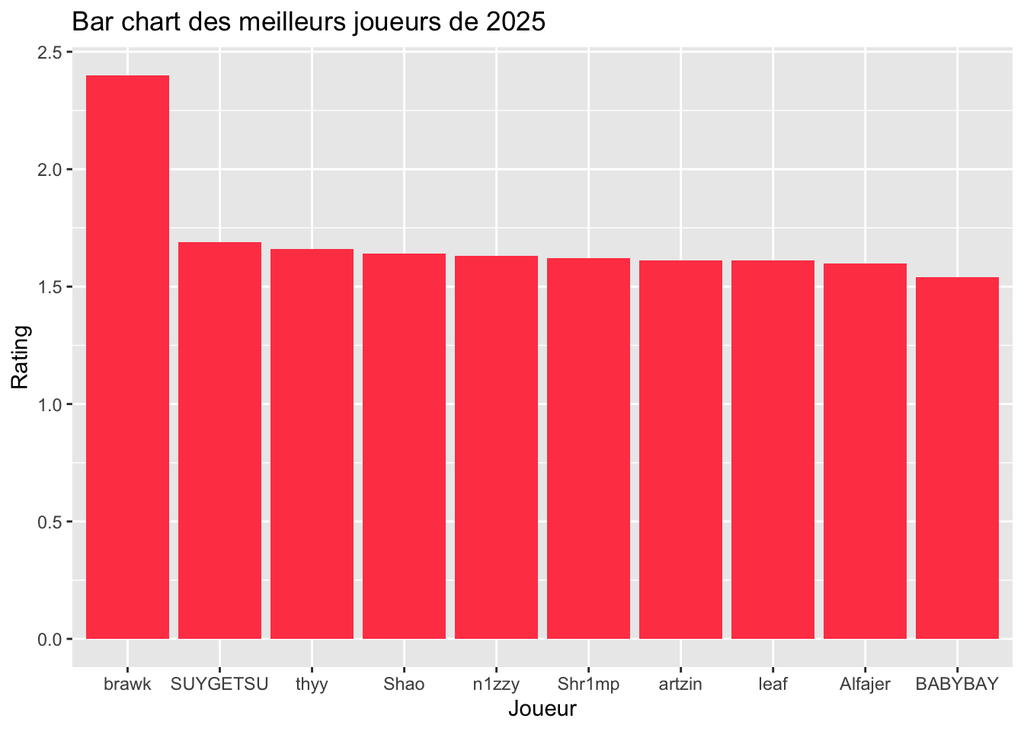

## Line Chart de l’évolution des meilleurs joueurs

Voyant que les 10 meilleurs joueurs changent régulièrement, nous avons souhaité vérifier si les meilleurs joueurs restent dans le top 10 plusieurs années d’affilée

[figure not shown]

## Interprétation

Le choix de représentation nous amène à observer que les premiers joueurs changent chaque année et que donc il est très difficile d’observer la progression de seulement les meilleurs joueurs. Le dernier graphique montre d’ailleurs que chaque joueur n’apparait jamais plusieurs fois dans le top 10. Il est donc impossible d’en percevoir l’évolution.

# 4. Qui sont les joueurs les plus forts en clutch ?

Être capable de retourner une situation désespérée est un atout considérable pour un joueur professionnel de Valorant. Le clutch est le fait de remporter une manche en étant le dernier membre de son équipe, tout en devant se battre contre plusieurs adversaires. Nous allons voir quels joueurs se retrouvent le plus souvent en situation de clutch (seul contre tous), et lesquels s’en sortent le mieux. Nous utiliserons la [source n°3](https://www.kaggle.com/datasets/ryanluong1/valorant-champion-tour-2021-2023-data)

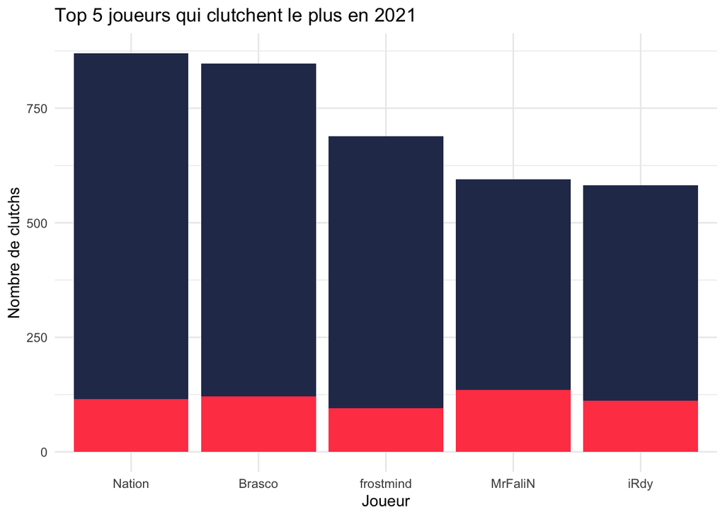

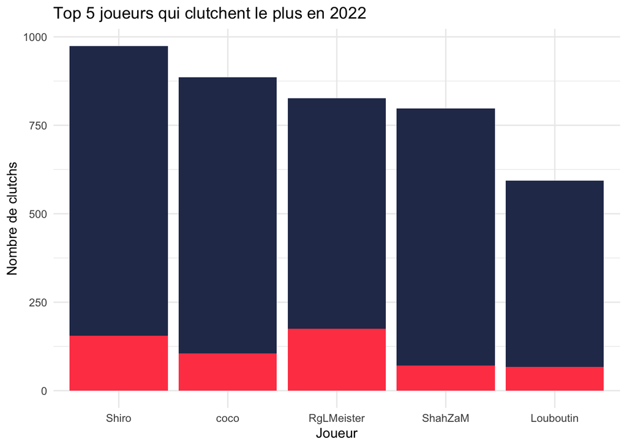

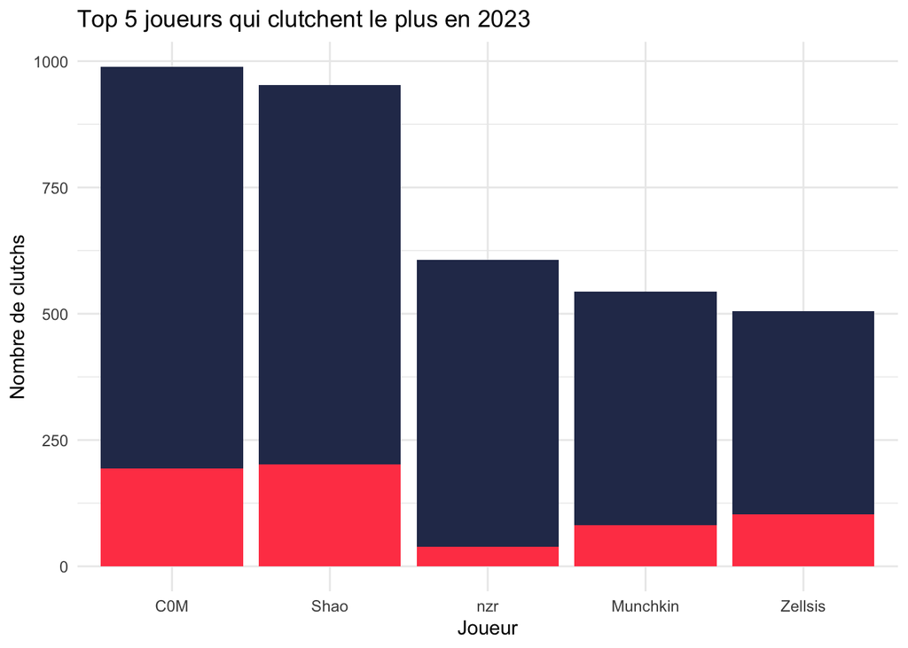

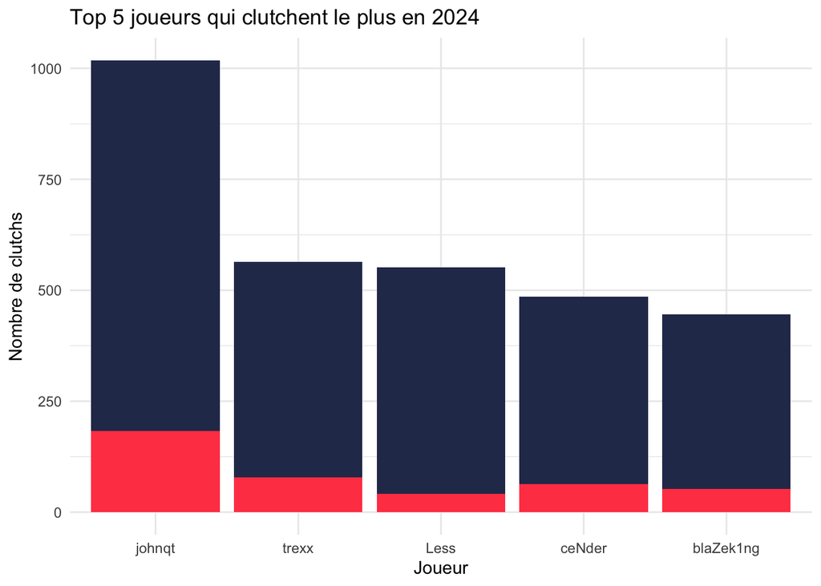

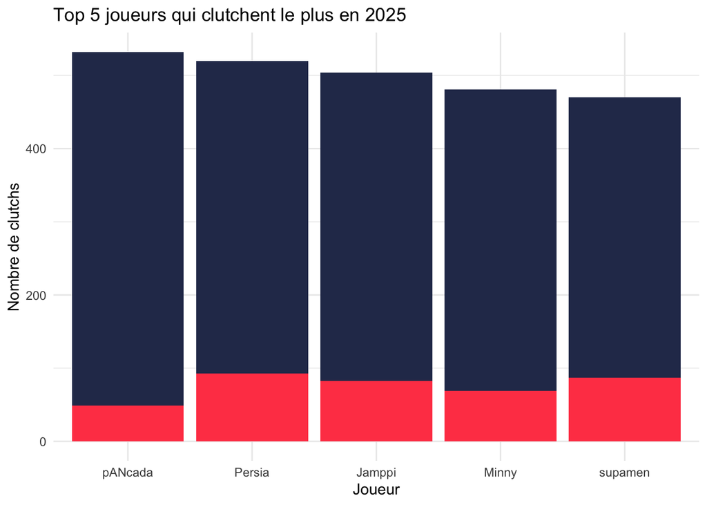

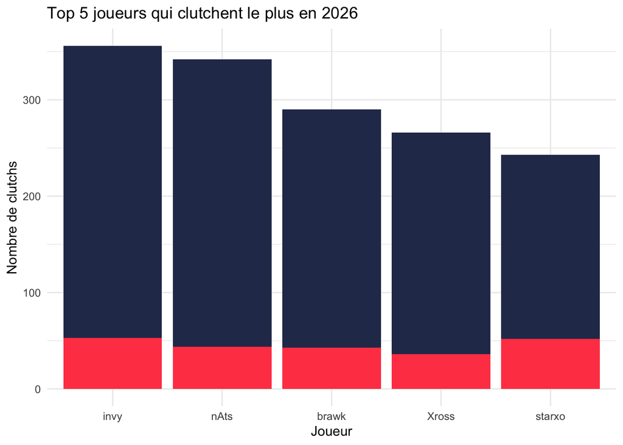

## Interprétation

On a beaucoup d’informations intéressantes sur ces graphes. Déjà, on voit que d’une année à l’autre, les joueurs ne sont pas les mêmes. On voit donc qu’il n’existe pas de joueur spécialement meilleur que les autres dans ces situations. On voit également que la quantité de clutchs varie grandement d’une année à l’autre. Ce n’est pas parce que ces situations sont plus ou moins rares, mais parce que dans certaines années, il y a eu moins de matchs. En 2021, car le jeu venait de sortir, et donc la scène compétitive comptait moins de joueurs, et en 2025 et 2026 car le dataset ne répertorie pas tous les matchs de ces années. On remarque cependant un point commun chez tous les joueurs présents dans ce tableau : ils jouent principalement des contrôleurs ou sentinelles, c’est à dire des agents servant de soutien aux duellistes. On peut expliquer cela car ces personnages sont souvent placés en retrait, et survivent généralement plus longtemps que ceux qui cherchent à se battre.

# 5. Quelles cartes sont orientées attaque ou défense ?

Les cartes ne sont pas toujours équilibrées pour les attaquants ou les défenseurs. Si l’une d’entre elles favorise les défenseurs, on pourra expliquer en partie leurs victoires répétées.

On étudiera d’abord pour les joueurs normaux, puis on verra si les pros sont aussi sujets à ces déséquilibres. Pour cela, on va étudier les winrates propres à chaque map en fonction des deux camps possibles (Attacker ou Defender).

## Pour tous les joueurs

Commençons par étudier les données concernant les joueurs lambda grâce à [cette ressource](https://blitz.gg/valorant/stats/maps?act=ev25actvi) qui nous donne les taux de victoire pour les côtés attaquant et défenseur sur chaque map pour toute une saison de 2025.

Faisons une visualisation:

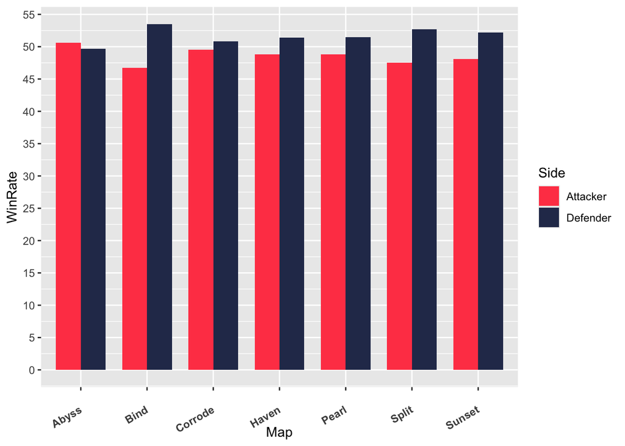

## Pour les joueurs professionnels

Voyons maintenant si les joueurs professsionnels ont des résultats similaires, ou s’ils ont peut-être plus d’écarts.

Ici on utilise un tableau relatif aux stats des maps de l’année 2025 des compétitions ESports.

Faisons une visualisation similaire à la première:

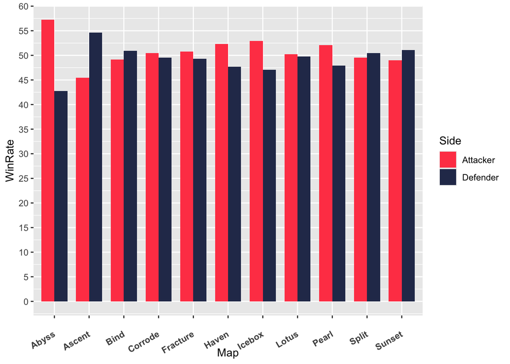

## Interprétation

On remarque qu’il y a plus de maps chez les pros que pour les joueurs publics. C’est sans doute car les maps tournent régulièrement en public comme en tournoi, donc on ne peut pas faire une comparaison pour chaque map ici. Mais c’est tout de même intéressant de toutes les garder pour constater si les écarts persistent ou sont plus impportants en règle générale.

# 7 & 8. Quelles sont les meilleures équipes par année ?

Nous répondons aux questions 7 & 8 en simultané dans une question un peu plus grande car nous les considérons très complémentaires et plus faciels à étudier de cette manière.

On importe les données des Valorant Champion 2021-2025 en récupérant:

- Le winrate par équipe
- Le nombre de changements au roster entre 2022 et 2025

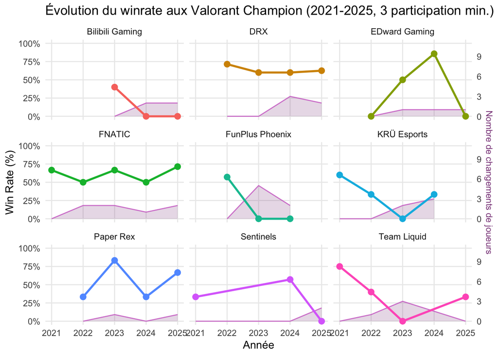

## Interprétation

Le nombre de changement de joueurs semble indiquer que les changements de joueurs ont pour conséquence de faire baisser les performances de l’équipe, tandis qu’un taux de changement bas est souvent corrélé avec des performances stables sur le long terme.

# 9. Quel est le lien entre nombre de kills et victoire ?

On veut voir si il y a un lien entre le nombre de kills et gagner la manche, ou si la victoire est plutôt liée à la coordination autour de l’objectif. On peut étudier la différence entre des joueurs normaux et pros.

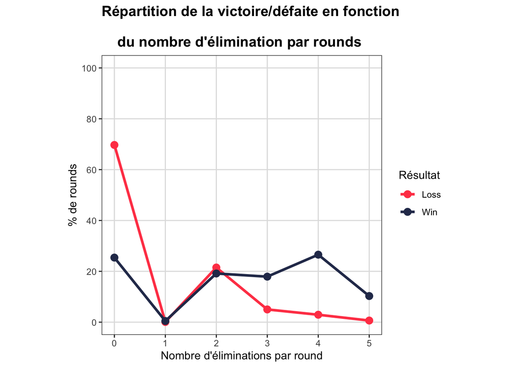

## Interprétation

Comme on peut le voir dans ce grpahique, le nombre d’éliminations et la victoire sont corrélés de façon particulière. Dans le cas d’un coach d’équipe E-Sport, il peut être capital de savoir comment ceux-ci sont liés. On voit qu’à 1 kill, le nombre de parties est quasiment 0, car les manches où le nombre d’éliminations est de 1 est extrêmement rare, les joueurs répliquent lorsqu’un de leur allié est éliminé. On voit aussi que 2 éliminations ne sont souvent pas suffisantes, mais que quand la majorité de l’équipe adverse est éliminée, c’est très souvent le signe d’une victoire. Dans le cas contraire, ne pas faire d’élimination montre que dans l’écrasante majorité des cas, on a subit une défaite.

# 10. Comment la visée ou le KDA influe sur le rang ?

Pour cela, nous pouvons utiliser le dataset Stats and Ranks of 2600 Valorant Players, qui comprend les stats pertinentes pour cette question et concerne des joueurs amateurs.

On peut commencer par visualiser le KD moyen pour chaque rang.

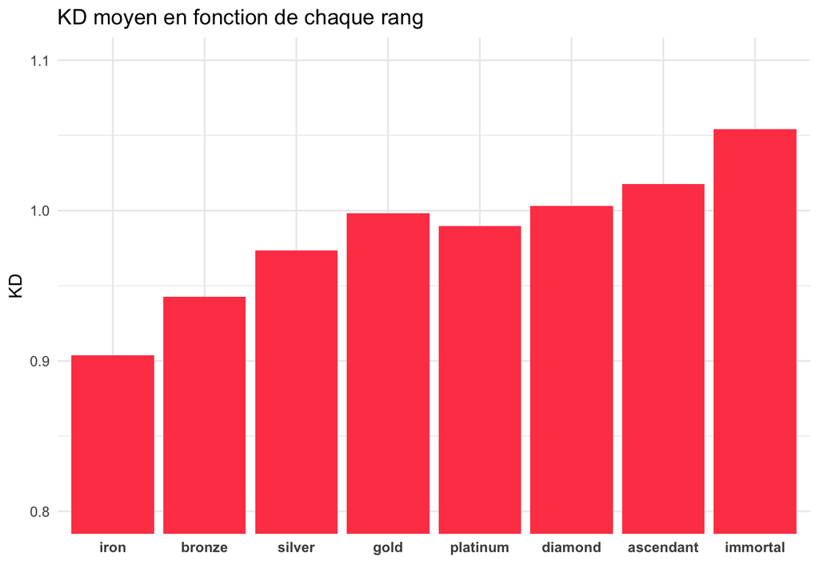

Les rangs sont ici disposés dans l’ordre de progression du jeu. On remarque clairement une corrélation entre la hauteur du KD et le rang. Le KD augmente avec le rang. Donc en moyenne, les joueurs avec les meilleurs KD sont aussi les joueurs les plus haut placés en compétitif.

Maintenant, nous pouvons refaire cette même observation mais avec une mesure de la visée. Il est très difficile en général de mesurer la qualité de la visée des joueurs. Ici, les données que l’on peut utiliser pour mesurer la qualité très globale de la visée sont le nombre de headshots et le nombre de kills. En faisant un ratio headshots / kills, on peut avoir une idée globale de à quel point un joueur vise bien. Utilisons donc ce ratio et faisons un graphique similaire avec celui-ci.

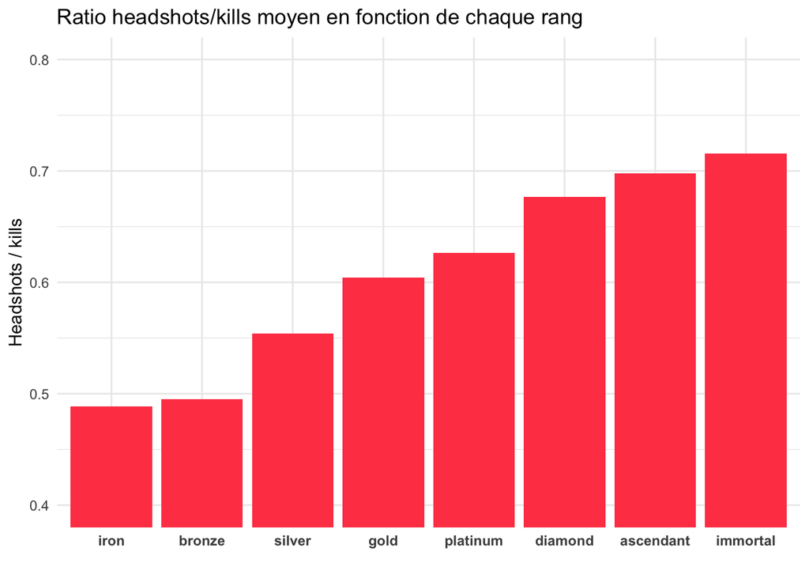

On remarque à nouveau une évolution frappante du ratio en fonction du rang.

## Interprétation

Nous pouvons conclure que nos intuitions premières étaient justes: en général, les profils de joueurs ayant des KD élevés et une bonne visée sont systématiquement des joueurs de haut rang; et à l’inverse, ceux avec les KD et les visées moins bonnes se trouvent dans les premiers rangs.

# 11. Impact des parties précédentes sur l’actuelle

[figure not shown]

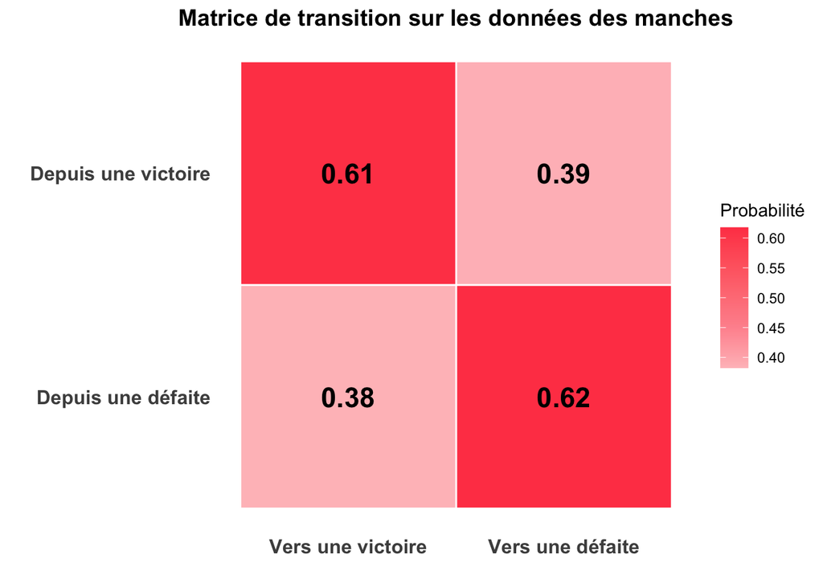

## Interprétation

# 12. Quelle est la meilleure composition d’équipe ?

En tant que coach, il est très important d’être à jour sur la méta, c’est à dire savoir quels agents sont forts sur quelles cartes. Plus que cela, on peut observer quelles synergies d’agents sont forts, et à fortiori quelles compositions d’équipes sont à la fois populaires et puissants. Cela est notamment utile pour pouvoir analyser leur plan de jeu afin de le reproduire, ou de le contrer.

On importe les données des Valorant Champion 2025 en récupérant:

- Le score de chaque équipe sur chaque carte à chaque rencontre
- Les statistiques de chaque joueur de chaque sur chaque carte et rencontre

[figure not shown]